# LAB 04

Nana Ama Obeng Nti

## QUESTION 1

The number of points scored by each team in a tournament is normally distributed, with mean = 32 and standard deviation = 7. What is the probability of:

### Question 1a.i

A team scoring 20 points or fewer?

```r
less.20 <- pnorm(20,32,7)
less.20
```

```
[1] 0.04323813
```

### Question 1a.ii

Plot the density function and shade the area.

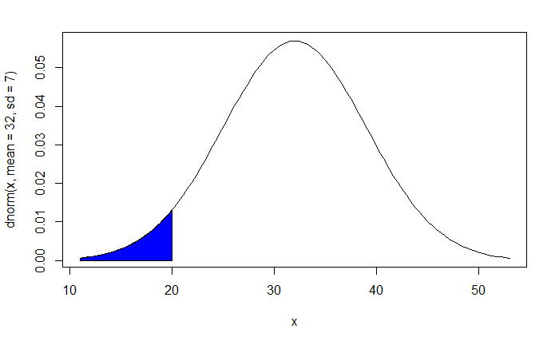

```r
curve(dnorm(x, mean = 32, sd = 7), from = 11, to = 53)
pt.x <- c(11,seq(11,20,by=0.01),20)
pt.y <- c(0, dnorm(seq(11,20,by=0.01),mean = 32,sd = 7),0)
polygon(pt.x, pt.y,col = "blue")
```

### Question 1b.i

A team scoring more than 35 points

```r
more.35 <- pnorm(35,32,7,lower.tail = F)
more.35
```

```
[1] 0.3341176
```

### Question 1b.ii

Plot the density function and shade the area.

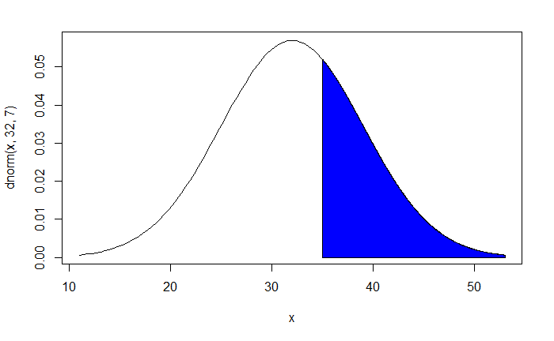

```r
curve(dnorm(x,32,7),from = 11, to = 53)
pt.x <- c(35,seq(35,53,0.01),53)
pt.y <- c(0,dnorm(seq(35,53,0.01),32,7),0)
polygon(pt.x,pt.y,col = "blue")
```

### Question 1c.i

A team scoring between 20 and 40 points

```r
btwn <- diff(pnorm(c(20,40),32,7))
btwn
```

```
[1] 0.8302129
```

### Question 1c.ii

Plot the density function and shade the area

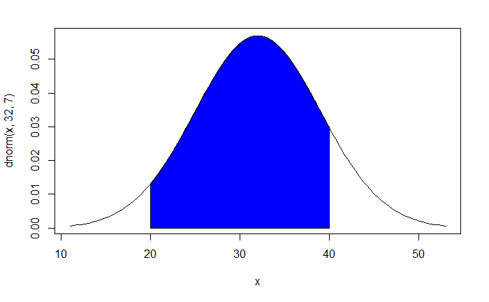

```r
curve(dnorm(x,32,7),from = 11, to = 53)
pt.x <- c(20,seq(20,40,0.01),40)
pt.y <- c(0, dnorm(seq(20,40,0.01),32,7),0)
polygon(pt.x,pt.y,col = "blue")
```

## QUESTION 2

The number of comments per post on a social media site is exponentially distributed, with the average post receiving ten comments. What percentage of posts get

### Question 2a.i

Fewer than three comments

```r
few.3 <- pexp(3,rate = 1/10)
few.3
```

```
[1] 0.2591818
```

### Question 2a.ii

Plot the density function and shade the area

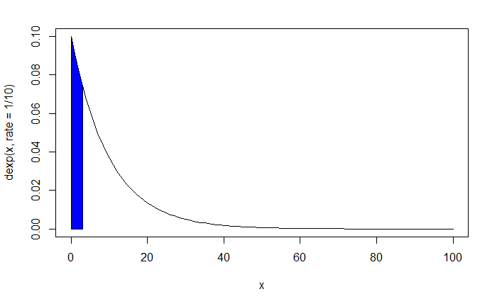

```r
curve(dexp(x, rate = 1/10),from = 0, to = 100)
pt.x <- c(0,seq(0,3,by=0.01),3)
pt.y <- c(0,dexp(seq(0,3,0.01),rate = 1/10),0)
polygon(pt.x,pt.y,col = "blue")
```

### Question 2b.i

More than 20 comments

```r
more.20 <- pexp(20,1/10,lower.tail = F)
more.20
```

```
[1] 0.1353353
```

### Question 2b.ii

Plot the density function and shade the area

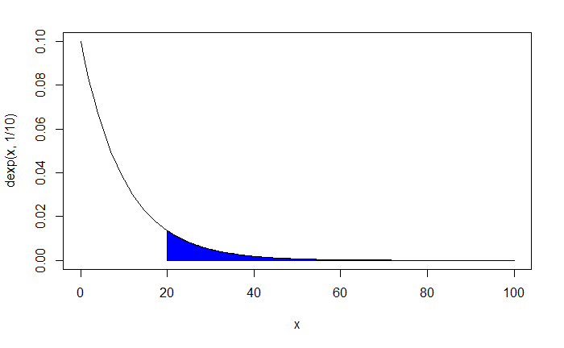

```r
curve(dexp(x,1/10),from = 0, to = 100)
pt.x <- c(20,seq(20,100,0.01),100)
pt.y <- c(0,dexp(seq(20,100,0.01),1/10),0)
polygon(pt.x,pt.y,col = "blue")
```

### Question 2c.i

Between five and ten comments

```r
btwn <- diff(pexp(c(5,10),1/10))
btwn
```

```
[1] 0.2386512
```

### Question 2c.ii

Plot the density function and shade the area

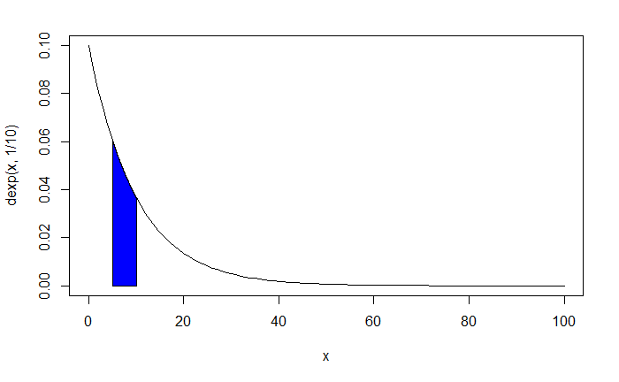

```r
curve(dexp(x,1/10),from = 0, to = 100)
pt.x <- c(5,seq(5,10,0.01),10)
pt.y <- c(0,dexp(seq(5,10,0.01),1/10),0)
polygon(pt.x,pt.y,col = "blue")
```

## QUESTION 3

Basic raster creation and calculation

### Question 3a.i

Create a first raster (30 rows and 30 columns) and assign values to the raster based on random values from a uniform distribution

```r
library(raster)
set.seed(10)
ras.1 <- raster(nrows=30,ncols=30,xmn=0,xmx=30,ymn=0,ymx=30)
ras.1
```

```
class       : RasterLayer
dimensions  : 30, 30, 900  (nrow, ncol, ncell)
resolution  : 1, 1  (x, y)
extent      : 0, 30, 0, 30  (xmin, xmax, ymin, ymax)
coord. ref. : +proj=longlat +datum=WGS84 +ellps=WGS84 +towgs84=0,0,0
```

### Question 3a.ii

Plot the raster and the histogram.

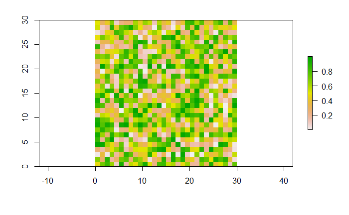

```r
ras.1[] = runif(ncell(ras.1))
plot(ras.1)
```

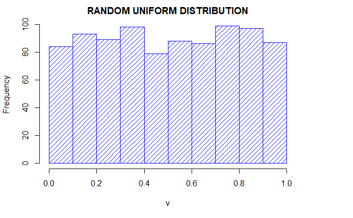

```r
hist(ras.1, main = "RANDOM UNIFORM DISTRIBUTION", col = "blue", density = 15)
```

### Question 3b.i

Create a second raster (30 rows and 30 columns) and assign values to the raster based on random values from a normal distribution

```r
set.seed(100)
ras.2 <- raster(nrows=30,ncols=30,xmn=0,xmx=30,ymn=0,ymx=30)
ras.2
```

```
class       : RasterLayer
dimensions  : 30, 30, 900  (nrow, ncol, ncell)
resolution  : 1, 1  (x, y)
extent      : 0, 30, 0, 30  (xmin, xmax, ymin, ymax)
coord. ref. : +proj=longlat +datum=WGS84 +ellps=WGS84 +towgs84=0,0,0
```

### Question 3b.ii

Plot the raster and the histogram

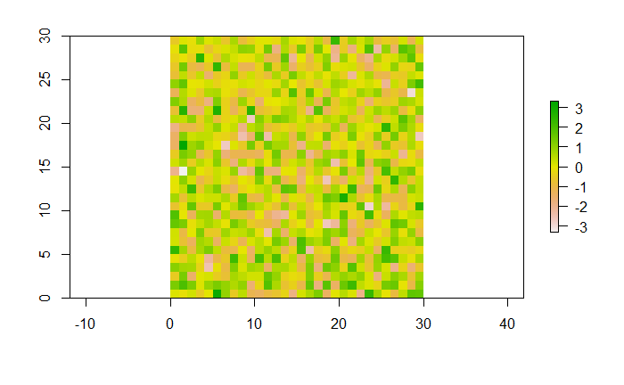

```r
ras.2[] = rnorm(ncell(ras.2))
plot(ras.2)
```

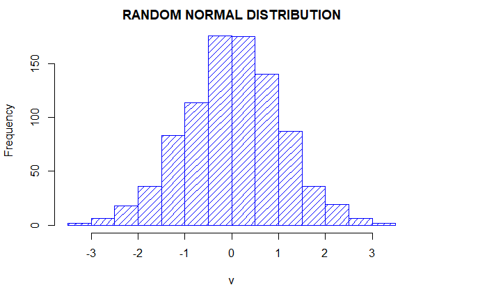

```r
hist(ras.2, main = "RANDOM NORMAL DISTRIBUTION", col = "blue", density = 15)
```

### Question 3c.i

Create a third raster (30 rows and 30 columns) and assign values to the raster based on cell-by-cell addition of the first raster and the second raster

```r
ras.3 <- ras.1 + ras.2
ras.3
```

```
class       : RasterLayer
dimensions  : 30, 30, 900  (nrow, ncol, ncell)
resolution  : 1, 1  (x, y)
extent      : 0, 30, 0, 30  (xmin, xmax, ymin, ymax)
coord. ref. : +proj=longlat +datum=WGS84 +ellps=WGS84 +towgs84=0,0,0
data source : in memory
names       : layer
values      : -2.757517, 4.027013  (min, max)
```

### Question 3c.ii

Plot the raster and the histogram

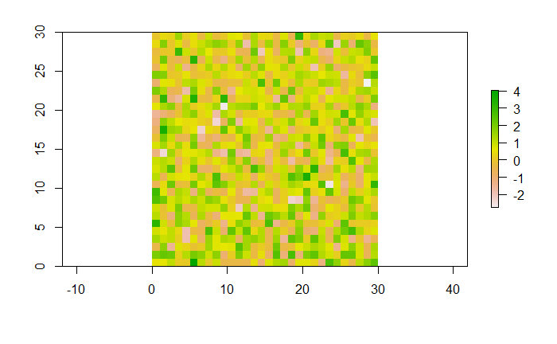

```r
plot(ras.3)
```

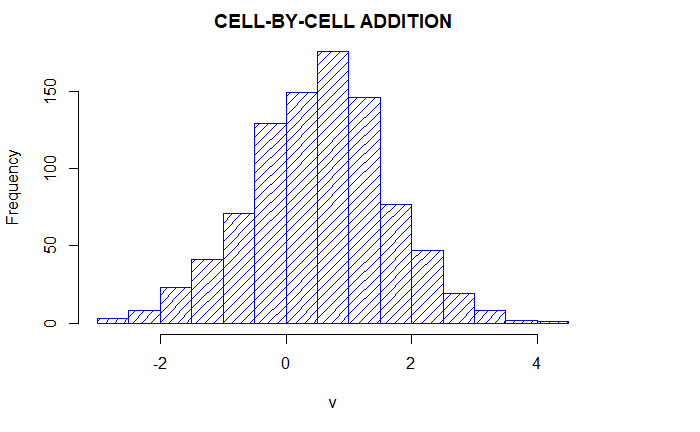

```r
hist(ras.3, main = "CELL-BY-CELL ADDITION", col = "blue", density = 15)
```

### Question 3d.i

Calculate the mean value of the third raster.

```r
mean(ras.3)
```

```
class       : RasterLayer
dimensions  : 30, 30, 900  (nrow, ncol, ncell)
resolution  : 1, 1  (x, y)
extent      : 0, 30, 0, 30  (xmin, xmax, ymin, ymax)
coord. ref. : +proj=longlat +datum=WGS84 +ellps=WGS84 +towgs84=0,0,0
data source : in memory
names       : layer
values      : -2.757517, 4.027013  (min, max)
```

```r
mn <- cellStats(ras.3,mean)
mn
```

```
[1] 0.5363611
```

### Question 3d.ii

Reclassify the third raster into a binary image: 1 (cell value > mean value) and 0 (cell value <= mean value)

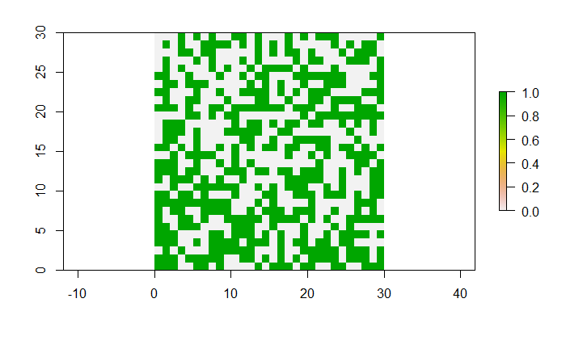

```r
ras.3[ras.3 <= mn] <- 0
ras.3[ras.3 > mn] <- 1
plot(ras.3)
```

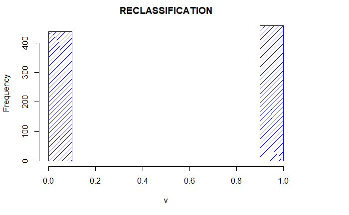

```r
hist(ras.3, main = "RECLASSIFICATION", col = "blue", density = 15)
```

### Question 3d.iii

Save the reclassified image to your working directory as a TIFF image

```r
library(rgdal)
writeRaster(ras.3, filename = "ras.3.tif", format = "GTiff", overwrite = T)
read = raster("ras.3.tif")
```